# ETO5513 Team Project

Gun Ho Jang & Rylie Douglas

2024-11-29

# Introduction

With the conclusion of the COP29 UN Climate Conference in Azerbaijan, it is clear that climate change remains one of the most challenging issues to tackle in the 21st century, with predictions of widespread loss and socioeconomic disruption if global action fails (Pearce (2024)). Understanding the trends of temperature changes is a critical step in developing strategies for climate mitigation and adaptation to begin responding to the problem. This report exmaines historical average surface temperature data from 1940 to 2010 in order to provide insights into long-term global and regional temperature patterns and assessing the rate of change.

This analysis uses decadal surface temperature data (1940-2010) from [Our World in Data](https://ourworldindata.org/grapher/decadal-average-surface-temperature) enabling the analysis of long-term temperature patterns. The dataset comprises three key variables: Entity (categorical variable representing individual country names and their geographical boundaries), Year (discrete numerical variable with eight decadal time points from 1940 to 2010 at 10-year intervals), and mean surface temperatures (continuous numerical variable measuring average temperatures in degrees Celsius for each country per decade). These measurements enable comparison of temperature changes across different geographical regions throughout the 70-year period.

The macro-level analysis focuses on the global trends in average surface temperature. This section employs visualisations, including box-and-whisker plots and scatter plots, along with regression techniques to explore the global trends and forecast future changes. The micro-level section examines global temperature patterns at the country level, analysing both sustained changes and periodic fluctuations between 1940 and 2010. The analysis focuses on identifying specific regional patterns of temperature change and variability, focusing on warming trends across different climatic zones.

## Section 1 - Macro Level - Gun Ho Jang

The macro-level overview of the decadal average surface temperature globally will be addressed through the following questions:

1. What is the global trend for average surface temperatures by decade (from 1940 to 2010)?
2. Using regression analysis techniques, what is the expected temperature change in the coming decades?

### Research Question 1: What is the global trend for average surface temperatures by decade (from 1940 to 2010)?

The dataset is prepared for analysis by loading into a data frame.

```
## [1] "The dataset contains 0 N/A values."
```

No missing values were found, so other data cleaning can be completed: the column headers are renamed, and the ‘Code’ column is removed as the Country column will be sufficient for country identification.

The decadal trends between 1940 and 2010 for the global average surface temperature are summarised as follows:

Table 1: Global Average Surface Temperature by Decade (1940-2010)

| Decade | Global Average Surface Temperature (°C) |
| --- | --- |
| 1940 | 17.51 |
| 1950 | 17.59 |
| 1960 | 17.69 |
| 1970 | 17.72 |
| 1980 | 17.94 |
| 1990 | 18.20 |
| 2000 | 18.52 |
| 2010 | 18.83 |

A box-and-whisker plot visualisation was selected to represent the distribution of global average surface temperatures across the decades, and to highlight any outliers that appear in the dataset.

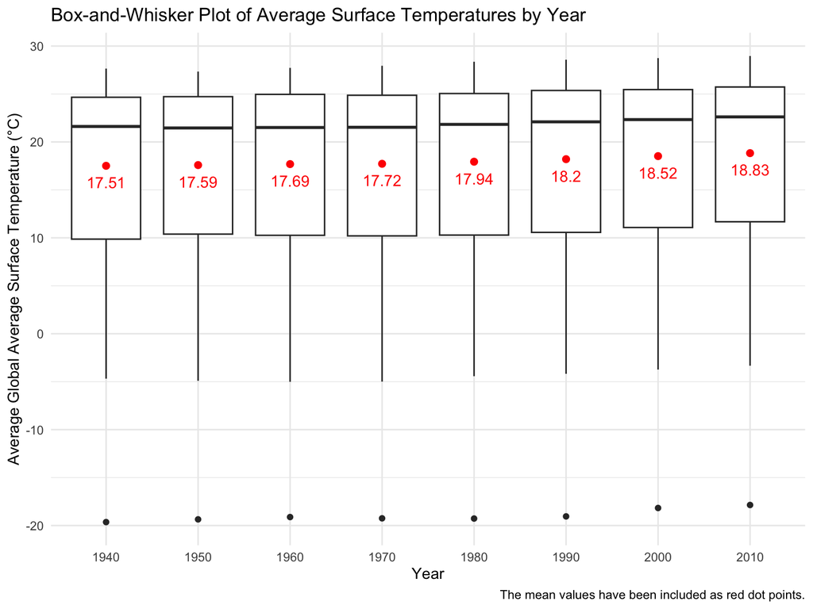

Both the table and the box-and-whisker plot demonstrate a steady increase in temperature from 1940 to 2010. The distribution shows an upward shift over the decades, with mean temperatures rising by 1.32°C during the observed period. Although this change appears small, the United Nations has warned that “every fraction of a degree of warming can result in discernible increases in the intensity and frequency of temperature and precipitation extremes” (United Nations (n.d.)).

The single low-temperature outlier in the plot corresponds with Greenland, reflecting the country’s Arctic conditions. However, even it has also exhibited a concerning warming trend during the observed period.

### Research Question 2: Using regression analysis techniques, what is the expected temperature change in the coming decades?

A simple linear regression model was used to analyse the relationship between the temperature and time variables, enabling prediction of future trends based on the historical data.

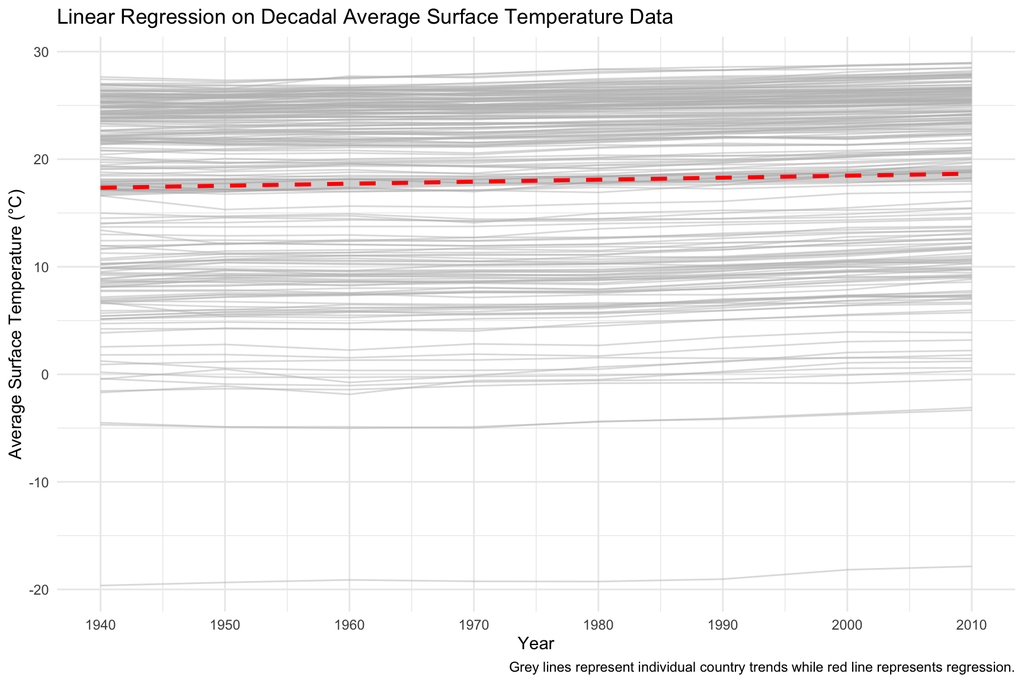

The reliability of the model is assessed in the summary table below.

Linear Regression Model Summary

| Term | Estimate | Std. Error | t-value | p-value |
| --- | --- | --- | --- | --- |
| (Intercept) | -18.8433 | 18.9901 | -0.9923 | 0.3212 |
| Year | 0.0187 | 0.0096 | 1.9403 | 0.0525 |

Predicted Temperatures for Next Several Decades

| Year | Predicted Temperature (°C) |
| --- | --- |
| 2020 | 18.84 |
| 2030 | 19.03 |
| 2040 | 19.21 |
| 2050 | 19.40 |

By 2050, the global average surface temperature is projected to reach approximately 19.40°C. However, the marginal relationship between year and temperature highlights the need for further analysis, including:

1. Incorporating additional factors such as greenhouse gas emissions or the effects of ocean currents.
2. Exploring non-linear modelling to capture complex temperature dynamics.
3. Validating predictions with future observed data to improve the model’s reliability.

## Section 2 - Micro level - Rylie Douglas

### Research Questions

This section investigates temperature variations at the country level, focusing on both long-term changes and temperature variability. The analysis addresses two primary research questions:

1. What are the patterns of temperature change across different climatic regions during this time period?
2. Which countries experienced the most unstable or variable temperatures during this time period?

### Results and Analysis

#### Research Question 1: Temperature Comparisons Across Countries

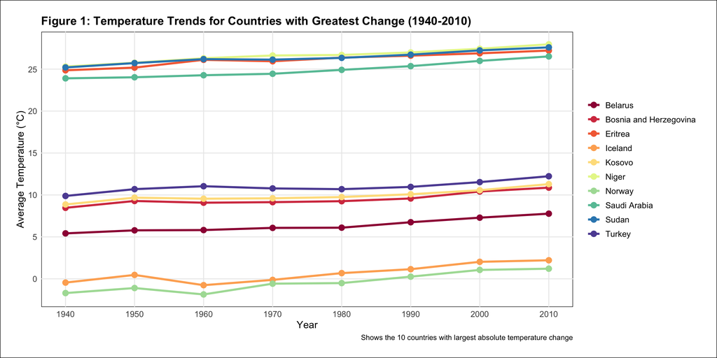

Figure 1 shows the trajectories of the ten countries with the most substantial temperature changes from 1940 to 2010. It can be seen that there is a slight upward trend of the yearly average temperatures for these countries over time, revealing particularly notable increases in Nordic regions.

Table 1: Countries with Greatest Temperature Change (1940-2010)

| Rank | Country | 1940 Mean Temperature (°C) | 2010 Mean Temperature (°C) | Total Change (°C) |
| --- | --- | --- | --- | --- |
| 1 | Norway | -1.70 | 1.21 | 2.91 |
| 2 | Iceland | -0.45 | 2.21 | 2.66 |
| 3 | Niger | 25.31 | 27.96 | 2.65 |
| 4 | Saudi Arabia | 23.90 | 26.52 | 2.61 |
| 5 | Kosovo | 8.87 | 11.29 | 2.42 |
| 6 | Bosnia and Herzegovina | 8.47 | 10.87 | 2.41 |
| 7 | Sudan | 25.20 | 27.60 | 2.39 |
| 8 | Eritrea | 24.86 | 27.22 | 2.35 |
| 9 | Belarus | 5.42 | 7.77 | 2.35 |
| 10 | Turkey | 9.88 | 12.23 | 2.35 |

Table 1 reveals diverse patterns of temperature change across different climatic regions. Norway experienced the most significant increase of 2.91°C (from -1.70°C to 1.21°C), followed by Iceland with a 2.66°C rise (from -0.45°C to 2.21°C). Niger also shows a significant 2.65°C increase from a much higher average temperature (25.31°C to 27.96°C). It can be seen that cold climate countries (Norway, Iceland and Belarus) and hot climate countries (Niger, Saudi Arabia, Sudan, Eritrea) appear in the top rankings. Total mean temperature changes affected various climatic regions, however cold regions displayed slightly larger absolute changes over the 70-year period.

#### Research Question 2: Temperature variability

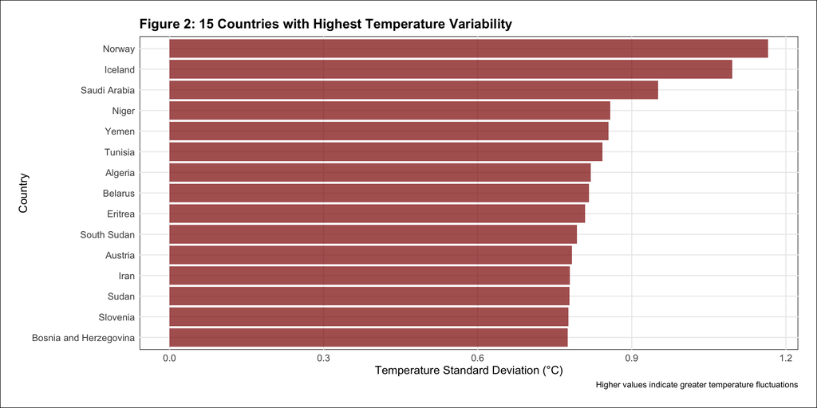

Figure 2 displays temperature variability across 15 countries from 1940 to 2010, measured by standard deviation (SD). Nordic countries show the most significant fluctuations, with Norway recording the highest variability (SD = 1.17°C), followed closely by Iceland (SD = 1.10°C). This pattern aligns with previous studies of Scandinavian climate variability, which have shown that Nordic regions experience greater temperature fluctuations due to their atmospheric circulation patterns and geographical position (Hanssen-Bauer et al. 2015). These findings suggest that northern regions, particularly Scandinavia, experienced more unstable temperature patterns compared to other global regions during this period, which is consistent with research showing that high-latitude areas are more sensitive to climate variations.

Table 2: Top 10 Countries with Highest Temperature Variability

| Rank | Country | Standard Deviation (°C) | Temperature Range (°C) | Coefficient of Variation (%) |
| --- | --- | --- | --- | --- |
| 1 | Norway | 1.17 | 3.07 | -290.82 |
| 2 | Iceland | 1.10 | 2.97 | 168.34 |
| 3 | Saudi Arabia | 0.95 | 2.61 | 3.82 |
| 4 | Niger | 0.86 | 2.65 | 3.22 |
| 5 | Yemen | 0.85 | 2.11 | 3.44 |
| 6 | Tunisia | 0.84 | 2.08 | 4.36 |
| 7 | Algeria | 0.82 | 2.34 | 3.59 |
| 8 | Belarus | 0.82 | 2.35 | 12.81 |
| 9 | Eritrea | 0.81 | 2.35 | 3.09 |
| 10 | South Sudan | 0.79 | 2.36 | 2.95 |

Table 2 presents temperature variability through three distinct metrics for the top 10 countries: standard deviation measuring absolute variability, temperature range indicating the interval between the extremes and coefficient of variation (CV) indicating relative variability. Norway has the highest standard deviation (1.17°C), temperature range (3.07°C) and has a negative coefficient of variation (-290.82%), which suggests extreme temperature fluctuations around its mean. Iceland shows the next highest CV of 168.34%. On the other hand, other high ranking countries like Saudi Arabia, Niger, and Yemen exhibit more moderate coefficients between 2-4%, this indicates that their temperature variations were less extreme relative to their higher mean temperatures.

# Conclusion

The macro-level analysis revealed a consistent rise in global average surface temperatures between 1940 and 2010, with an increase of 1.32°C over the 70-year period. Plot visualisations confirmed an upward shift in the average surface temperature values across the board, where even regions that experienced the coldest average temperatures (such as Greenland), reported warming trends. Linear regression modelling projected further increases in temperature, with average surface temperatures expected to reach 19.40°C by 2050 if current trends continue.

Analysis at the micro-level showed temperature changes between 1940-2010 revealed distinct regional patterns with an overall upward trend in mean temperatures globally. Nordic countries emerged as particularly sensitive to temperature changes, demonstrating both the highest absolute increases (Norway: 2.91°C) and greatest variability (Norway SD: 1.17°C, Iceland SD: 1.10°C). Notably, while hot-climate countries like Niger also experienced substantial changes (2.65°C increase), the most dramatic temperature fluctuations were consistently observed in northern regions. These patterns highlight the uneven geographical impact of global warming during this period.

In summary, the reported temperature increases from 1940 to 2010 at a macro and micro level reflect a substantial shift in global climate conditions and projections suggest considerable changes in global climate patterns in the decades ahead. These findings highlight the urgency of developing and implementing effective strategies to mitigate the effects of any further warming and possibly reverse the trend of rising temperatures.

# References

Hanssen-Bauer, I., E. J. Førland, I. Haddeland, H. Hisdal, S. Mayer, A. Nesje, J. E. Ø. Nilsen, et al. 2015. “Climate in Norway 2100 - Knowledge Basis for Climate Adaptation.” Technical Report NCCS report no. 1/2015. Norwegian Climate Service Centre.

Pearce, Joshua M. 2024. “COP29: Climate Change Could Kill Millions and World Leaders Must Work to Limit Fatalities.” https://theconversation.com/cop29-climate-change-could-kill-millions-and-world-leaders-must-work-to-limit-fatalities-244024.

United Nations. n.d. “1.5°c: What It Means and Why It Matters.” https://www.un.org/en/climatechange/science/climate-issues/degrees-matter.